```python
import pandas as pd
import numpy as np
from sklearn.metrics import accuracy_score
from sklearn.metrics import precision_recall_fscore_support
from datetime import datetime, timedelta
import seaborn as sns
from sklearn.preprocessing import MinMaxScaler
from sklearn.model_selection import train_test_split
from sklearn.linear_model import LogisticRegression
from sklearn.linear_model import LogisticRegressionCV
from sklearn.ensemble import RandomForestClassifier
from sklearn import metrics
import warnings
warnings.filterwarnings("ignore")
import matplotlib.pyplot as plt
%matplotlib inline
```

```python
df = pd.read_csv('employee_retention_data.csv')
last_date = datetime(2015,12,13)
```

# Data Preparation:

1) The goal is to predict employee retention and its main drivers.

2) The data includes the record of each employee in a row. From the "quit_date" column I can determine whether an employee has quit or not. Those with a date in "quit_date" column will have 1 as an indication of class of those who quit their jobs, and zero otherwise.

4) Since join_date is not a integer of categorical factor, I exploit a new feature called 'days_since_lastdate' to be able to use the information provided by 'join_date' column. as the question states the last day to analyze this data is 2015-12-13. the difference between this date (last_date= 2015-12-13) and each employees join_date is the number of days since an employee has joined the company. Feauture 'days_since_lastdate' can be used in a numeric format.

5) Since the number of records in the dataset and the number if employee_id's are thesame, and also eachemployee id is a unique number that does not provide information regarding an employees work or characteristics (otherwise the question would stated) therefore employee_id is taken out of the dataset. However, in the plots we can see that there is no association between the employee_id and other features or employee_id and whether an employee guits indicated churn column

6) 'dept' and 'company_id' are categorical data and need to be prepared to be fed to a classifier model. I am making a binary variables for each instance of the two features.

```python
print( 'Number of records in dataset = '+ str(len(df)) +
      ' which is equal to the number of unique employee ids = '+ str(len(df['employee_id'].unique())))
```

```
Number of records in dataset = 24702 which is equal to the number of unique employee ids = 24702
```

```python
emp_out_idx = df[df['quit_date'].isnull()==False].index
emp_in_idx = df[df['quit_date'].isnull()==True].index

df['churn'] = 0
df.loc[emp_out_idx, 'churn'] = 1
df['join_date'] = pd.to_datetime(df['join_date'],errors='raise')
df['quit_date'] = pd.to_datetime(df['quit_date'],errors='raise')


df['days_since_lastdate'] = last_date  - df['join_date']
df['days_since_lastdate'] = df['days_since_lastdate']/timedelta(days = 1)
```

```python
df.head()
```

|  | employee_id | company_id | dept | seniority | salary | join_date | quit_date | churn | days_since_lastdate |
| --- | --- | --- | --- | --- | --- | --- | --- | --- | --- |
| 0 | 13021.0 | 7 | customer_service | 28 | 89000.0 | 2014-03-24 | 2015-10-30 | 1 | 629.0 |
| 1 | 825355.0 | 7 | marketing | 20 | 183000.0 | 2013-04-29 | 2014-04-04 | 1 | 958.0 |
| 2 | 927315.0 | 4 | marketing | 14 | 101000.0 | 2014-10-13 | NaT | 0 | 426.0 |
| 3 | 662910.0 | 7 | customer_service | 20 | 115000.0 | 2012-05-14 | 2013-06-07 | 1 | 1308.0 |
| 4 | 256971.0 | 2 | data_science | 23 | 276000.0 | 2011-10-17 | 2014-08-22 | 1 | 1518.0 |

# Data Analysis:

Observation: the department is a categorical data that does not have an ascending or descending order. the bar chart shows whethe we can find a difference between department of those who have quit with those who staye.

Observation: scatter plots do not show an association between employee id/company id as featueres and the churn as the response variable. I mentioned that employe_id will be excluded from models previously.

Observation: company id have some relationship with dept when looking at the employees' salary. Therefore there might be a conditional relationship. Therefore, I will keep the company_id in the feautures and use a feature selection method (regularization) to exclude redunadancy and prevent high variance in the estimators.

Observation: seniority and salary are correlated and we expect to see that models that do feature selection exclude of of the two.

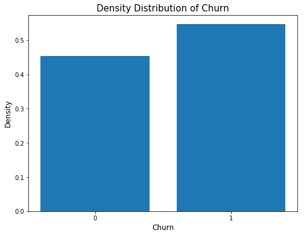

```python
plt.figure(figsize = (8,6))
plt.bar(df['churn'].unique(),[len(emp_out_idx)/len(df), len(emp_in_idx)/len(df)] )
plt.xlabel('Churn', fontsize = 12)
plt.xticks([1,0])
plt.ylabel('Density', fontsize = 12)
plt.title('Density Distribution of Churn', fontsize = 15)
plt.show()
```

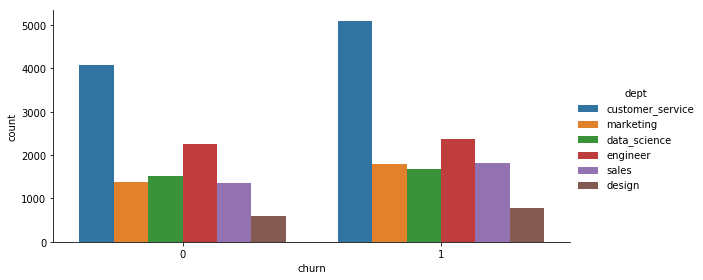

```python
df['churn'] = df['churn'].astype(str)
g = sns.catplot(x="churn", hue="dept", data=df, kind="count", height=4, aspect=2);
```

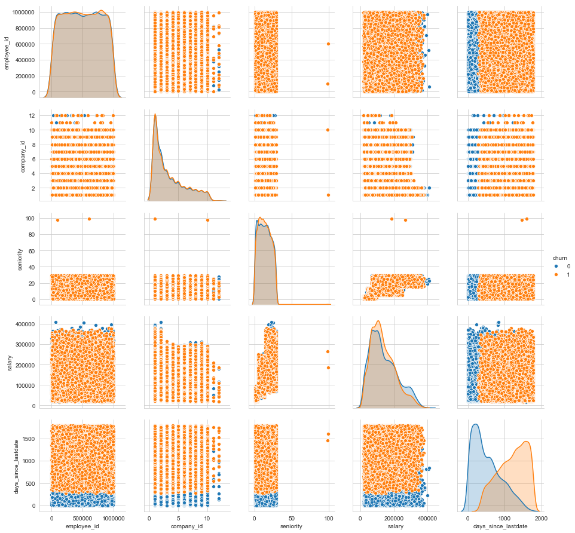

```python
sns.set_style("whitegrid")
sns.pairplot(df, hue="churn",vars=['employee_id', 'company_id', 'seniority', 'salary','days_since_lastdate']);
```

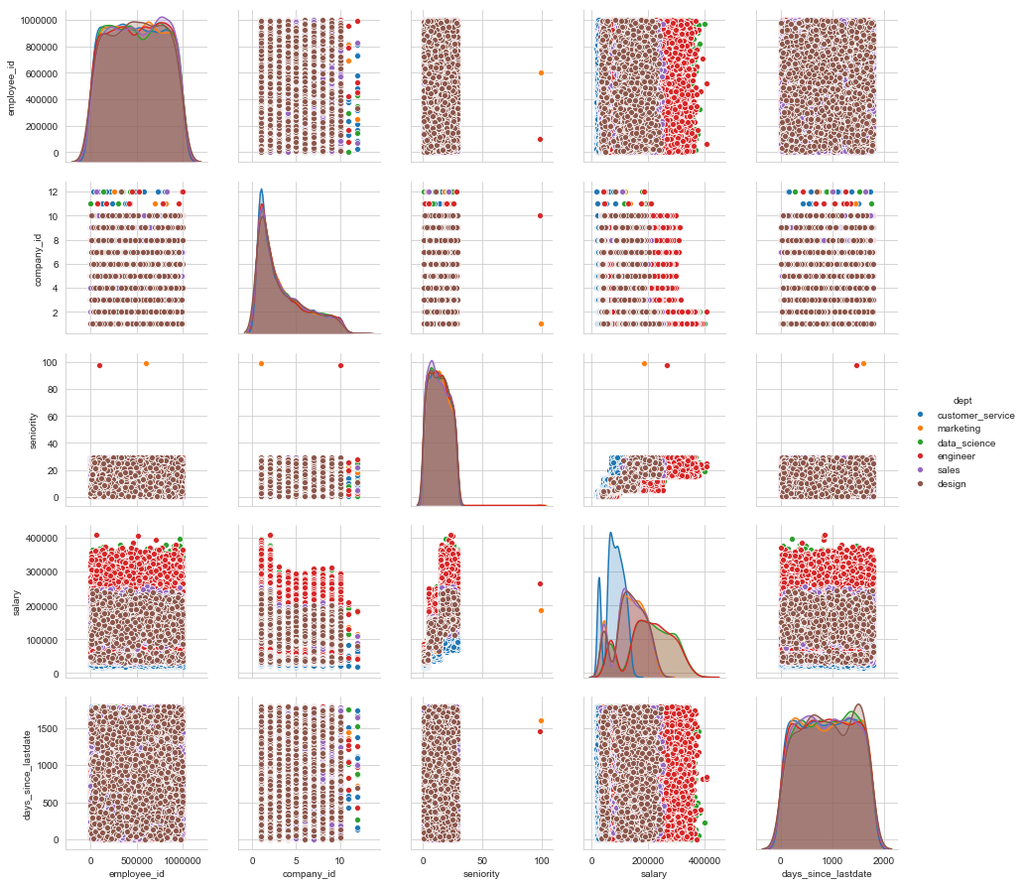

```python
sns.set_style("whitegrid")
sns.pairplot(df, hue="dept",vars=['employee_id', 'company_id', 'seniority', 'salary','days_since_lastdate']);
```

# Model Selection:

Due to having 3 non-categorical (integer and continous) features and 2 categorical features with a binary response variable, I used logistic regression as the first model and used the information at each step to build a better model. After turning 'company_id' and 'dept' into binary variables, I did the following:

1) In order to identify the best features to includein the model, I used regularization as means which is a non-subjective technique that selects the best set of features by penelilising those that are multicolinear, redundent or do not provide predictive power. therefore, I normalized data before splitting into test and train due to using regularization. Regularization also helps overfitting which will futhur be investigated.

2) I used crossvalidation on the train posrtion of data to better investigate the performance of models

3) Models are tuned to have better TEST_ERROR by metrics that measure the error in the portion of data that is unseen by the models to prevent overfitting.

# Metrics

The metrics selected for minimizing the test score is Accuracy, Area under the ROC curve (AUC), and I also look at the precision-recall trade off (F1 score is used as a measure for representing the trade off) with confusion matrix.

- In this problem although predicting those who will churn may have greater value, but since the data does not have class imbalance, accuracy along with AUC thouroghly explains goodness of fit.
- We care about identifying those that do not quit, however if we cared as much about them as we care about those who quit, we would also include specifity. But those who quit are those who cause more cost for the company.

# Finding Main Factors of Churn:

For identifying best drivers of retention, coefficients generated by the Ridge model (L2) is used for this purose and interpretation; since coefficients do not fluctuate on small data changes as is the case with unregularized or L1 model.

The reason is that when using unregularized model, features can be correlated and therefore the variance of coefficients may be amplified. This means if a slightly different data set was used to train the model, there could be large variations in coefficients. Similarly, due to the nature of Lasso, small data changes can cause therefore, the resulting set of active features may change.

```python
feature_cols = ['company_id', 'dept', 'seniority', 'salary', 'days_since_lastdate']
data = df[feature_cols]
```

```python
cat_vars=['company_id','dept']
for var in cat_vars:
    cat_list='var'+'_'+var
    cat_list = pd.get_dummies(data[var], prefix=var)
    data1=data.join(cat_list)
    data=data1
cat_vars=['company_id','dept']
data_vars=data.columns.values.tolist()
to_keep=[i for i in data_vars if i not in cat_vars]
data=data[to_keep]
```

```python
cols_to_transform = ['seniority','salary','days_since_lastdate']
data['seniority'] = (data['seniority'] - data['seniority'].min())/(data['seniority'].max() - data['seniority'].min())
data['salary'] = (data['salary'] - data['salary'].min())/(data['salary'].max() - data['salary'].min())
data['days_since_lastdate'] = (data['days_since_lastdate'] - data['days_since_lastdate'].min())/(data['days_since_lastdate'].max() - data['seniority'].min())
```

```python
X_train, X_test, y_train, y_test = train_test_split(data, df['churn'].astype(int), test_size=0.33, random_state=42)
```

```python
logmodel = LogisticRegression().fit(X_train, y_train)
predicted_classes = logmodel.predict(X_test)
predicted_probs = logmodel.predict_proba(X_test)
accuracy = accuracy_score(y_test,predicted_classes)
parameters = logmodel.coef_
parameters, accuracy
```

```
(array([[ 1.192871  , -0.98662483,  6.73029734, -0.26163096, -0.36005655,
         -0.29656556, -0.18068315, -0.20599129, -0.28885287, -0.2070604 ,
         -0.25320612, -0.21105753, -0.17150078,  0.38688699, -0.18917659,
         -0.43424446, -0.44782931, -0.37309782, -0.47922155, -0.2115054 ,
         -0.29299627]]), 0.7872914622178606)
```

```python
# Confusion matrix
pd.crosstab(y_test, predicted_classes, rownames=['Actual'], colnames=['Predicted'])
```

| Predicted Actual | 0 | 1 |
| --- | --- | --- |
| 0 | 2811 | 860 |
| 1 | 874 | 3607 |

```python
precision_recall_fscore_support(y_test, predicted_classes, average='macro')
```

```
(0.7851496531628444, 0.7853428298093996, 0.7852438705123166, None)
```

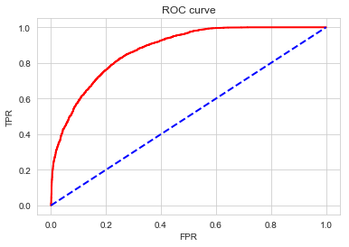

```python
prob_retention =[]
for i in range(len(predicted_probs)):
    prob_retention.append(predicted_probs[i][1])
##Computing false and true positive rates
fpr, tpr, thresholds = metrics.roc_curve(y_test, prob_retention)
plt.figure()
##Adding the ROC
plt.plot(fpr, tpr, color='red',lw=2, label='ROC curve')
##Random FPR and TPR
plt.plot([0, 1], [0, 1], color='blue', lw=2, linestyle='--')
##Title and label
plt.xlabel('FPR')
plt.ylabel('TPR')
plt.title('ROC curve')
plt.show()
```

```python
auc = metrics.roc_auc_score(y_test, prob_retention)
auc
```

```
0.8743011368378767
```

```
<BarContainer object of 21 artists>
```

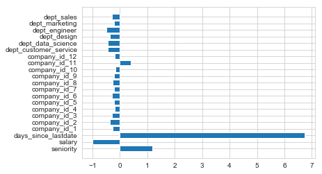

```python
plt.barh(X_train.columns, parameters[0])
```

# Improving Models:

1) Regularization: in order to find the balance in bias-variance tradeoff, I use regularization as measn to decrease variance of coefficients (the estimations) and therefore allowing bias to increase,which will result in prevention of overfitting.

Through L1 lasso regularization, I find the main drivers to include in the model and through L2, Ridge, i find the direction that each predictor affects the churn when all features are maintained. this helps identifying features that are inter-correlated when compared to direction in Lasso.

2) Cross Validation: for model selection, using CV avoids chosing models that overfit and help select models that adjust performance measures for data that is not seen by the model. therefore, it helps finding the predictive model that best represents data.

```
<BarContainer object of 21 artists>
```

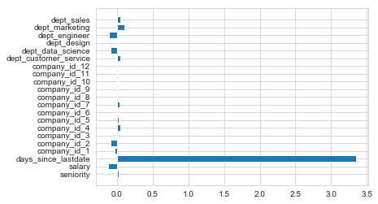

```python
logmodel_cv = LogisticRegressionCV(cv=5, random_state=0,multi_class='ovr').fit(X_train, y_train)
predicted_classes_cv = logmodel_cv.predict(X_test)
predicted_prob_cv = logmodel_cv.predict_proba(X_test)
accuracy_cv = accuracy_score(y_test,predicted_classes_cv)
parameters_cv = logmodel_cv.coef_
plt.barh(X_train.columns, parameters_cv[0])
```

```python
# Confusion matrix
pd.crosstab(y_test, predicted_classes_cv, rownames=['Actual'], colnames=['Predicted'])
```

| Predicted Actual | 0 | 1 |
| --- | --- | --- |
| 0 | 2743 | 928 |
| 1 | 788 | 3693 |

```python
prob_retention_cv =[]
for i in range(len(predicted_prob_cv)):
    prob_retention_cv.append(predicted_prob_cv[i][1])

prfs = precision_recall_fscore_support(y_test, predicted_classes_cv, average='macro')
auc = metrics.roc_auc_score(y_test, prob_retention_cv)
print ('Logistic Regression Model with CV: has accuracy of ' +str(accuracy_cv)+
       ', precision of ' +str(prfs[0])+ ', recall of ' +str(prfs[1])+ ', and AUC of '+str(auc) )
```

```
Logistic Regression Model with CV: has accuracy of 0.7894995093228655, precision of 0.7880057126568887, recall of 0.7856771205837705, and AUC of 0.8739743841715295
```

# Lasso Regularization

In order to get a better estimation on what are the main drivers of rentention Lasso (L1) is used.

Cross validation helps for getting a accuracy measure without overfifiing.

- as expected we see that Lasso model zeros out the seniority as it was correlated with the salary.

```
<BarContainer object of 21 artists>
```

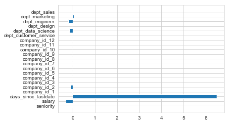

```python
logmodel_cv_l1 = LogisticRegressionCV(cv=5, random_state=0,multi_class='ovr',penalty='l1',solver = 'liblinear').fit(X_train, y_train)
predicted_classes_cv_l1 = logmodel_cv_l1.predict(X_test)
predicted_prob_cv_l1 = logmodel_cv_l1.predict_proba(X_test)
accuracy_cv_l1 = accuracy_score(y_test,predicted_classes_cv_l1)
parameters_cv_l1 = logmodel_cv_l1.coef_
plt.barh(X_train.columns, parameters_cv_l1[0])
```

```python
# Confusion matrix
pd.crosstab(y_test, predicted_classes_cv_l1, rownames=['Actual'], colnames=['Predicted'])
```

| Predicted Actual | 0 | 1 |
| --- | --- | --- |
| 0 | 2803 | 868 |
| 1 | 870 | 3611 |

```python
prob_retention_cv_l1 =[]
for i in range(len(predicted_prob_cv_l1)):
    prob_retention_cv_l1.append(predicted_prob_cv_l1[i][1])

pd.crosstab(y_test, predicted_classes_cv_l1, rownames=['Actual'], colnames=['Predicted'])
prfs= precision_recall_fscore_support(y_test, predicted_classes_cv_l1, average='macro')
log_prfs = prfs
auc = metrics.roc_auc_score(y_test, prob_retention_cv_l1)
print ('Logistic Regression Model with CV and Lasso: has accuracy of ' +str(accuracy_cv_l1)+
       ', precision of ' +str(prfs[0])+ ', recall of ' +str(prfs[1])+ ', and AUC of '+str(auc) )
```

```
Logistic Regression Model with CV and Lasso: has accuracy of 0.7868007850834151, precision of 0.7846715716693937, recall of 0.784699537397253, and AUC of 0.8743440554206565
```

# Ridge Regression

Shrinking features without allowing them to adopt zero helps finding the direction of each feature when all features simultaneously exist in the model.

Although both Lasso and Ridge models provide unique solutions, the coefficients from Ridge regression are stable if slightly different dataset was used to . train the model. as a results coefficients are reliable and can be interpreted for finding drives of retention.

```python
logmodel_cv_l2 = LogisticRegressionCV(cv=100, random_state=0,multi_class='ovr',penalty='l2').fit(X_train, y_train)
predicted_classes_cv_l2 = logmodel_cv_l2.predict(X_test)
predicted_prob_cv_l2 = logmodel_cv_l2.predict_proba(X_test)
accuracy_cv_l2 = accuracy_score(y_test,predicted_classes_cv_l2)
parameters_cv_l2 = logmodel_cv_l2.coef_
parameters_cv_l2_df = pd.DataFrame(logmodel_cv_l2.coef_)
predicted_probs_cv_l2 = logmodel_cv_l2.predict_proba(X_test)
```

```
<BarContainer object of 21 artists>
```

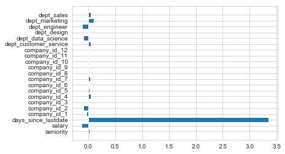

```python
plt.barh(X_train.columns, parameters_cv_l2[0])
```

```python
pd.crosstab(y_test, predicted_classes_cv_l1, rownames=['Actual'], colnames=['Predicted'])
```

| Predicted Actual | 0 | 1 |
| --- | --- | --- |
| 0 | 2803 | 868 |
| 1 | 870 | 3611 |

```python
prob_retention_cv_l2 =[]
for i in range(len(predicted_prob_cv_l2)):
    prob_retention_cv_l2.append(predicted_prob_cv_l2[i][1])

pd.crosstab(y_test, predicted_classes_cv_l2, rownames=['Actual'], colnames=['Predicted'])
prfs= precision_recall_fscore_support(y_test, predicted_classes_cv_l2, average='macro')
auc = metrics.roc_auc_score(y_test, prob_retention_cv_l2)
print ('Logistic Regression Model with CV and Ridge: has accuracy of ' +str(accuracy_cv_l2)+
       ', precision of ' +str(prfs[0])+ ', recall of ' +str(prfs[1])+ ', and AUC of '+str(auc) )
```

```
Logistic Regression Model with CV and Ridge: has accuracy of 0.7894995093228655, precision of 0.7880057126568887, recall of 0.7856771205837705, and AUC of 0.8739727428092983
```

```python
logmodel_cv_l2.score(X_train, y_train), logmodel_cv_l2.score(X_test, y_test)
```

```
(0.7954078549848943, 0.7894995093228655)
```

# Do we need more sofisticated models:

Why:

1) After turning the categorical features to binary variables, now most of the features are binary. A tree-based model can perform well when the number of categorical features increase due to the constant-point splits.

```
Logistic Regression Model with CV and Ridge: has accuracy of 0.7571148184494603, precision of 0.7547824491156814, recall of 0.7557270015819693, and AUC of 0.838321808032231
```

| Predicted Actual | 0 | 1 |
| --- | --- | --- |
| 0 | 2723 | 948 |
| 1 | 1032 | 3449 |

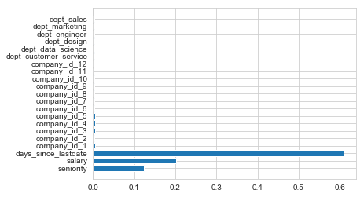

```python
# 10 trees:
rf = RandomForestClassifier(n_estimators = 10, random_state = 42,criterion='entropy')
rf.fit(X_train, y_train)
rf_importance10  = rf.feature_importances_
predicted_classes_rf = rf.predict(X_test)
predicted_prob_rf = rf.predict_proba(X_test)
plt.barh(X_train.columns, rf_importance10)

accuracy_rf = accuracy_score(y_test,predicted_classes_rf)

prob_retention_rf =[]
for i in range(len(predicted_prob_rf)):
    prob_retention_rf.append(predicted_prob_rf[i][1])
prfs= precision_recall_fscore_support(y_test, predicted_classes_rf, average='macro')
auc = metrics.roc_auc_score(y_test, prob_retention_rf)
print ('Logistic Regression Model with CV and Ridge: has accuracy of ' +str(accuracy_rf)+
       ', precision of ' +str(prfs[0])+ ', recall of ' +str(prfs[1])+ ', and AUC of '+str(auc) )
pd.crosstab(y_test, predicted_classes_rf, rownames=['Actual'], colnames=['Predicted'])
```

[output not shown]

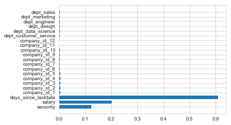

```python
# 50 trees:
rf = RandomForestClassifier(n_estimators = 50, random_state = 42,criterion='entropy')
rf.fit(X_train, y_train)
predicted_classes_rf = rf.predict(X_test)
predicted_prob_rf = rf.predict_proba(X_test)
rf_importance = rf.feature_importances_
accuracy_rf = accuracy_score(y_test,predicted_classes_rf)


plt.barh(X_train.columns, rf_importance)


prob_retention_rf =[]
for i in range(len(predicted_prob_rf)):
    prob_retention_rf.append(predicted_prob_rf[i][1])
prfs= precision_recall_fscore_support(y_test, predicted_classes_rf, average='macro')
auc = metrics.roc_auc_score(y_test, prob_retention_rf)
print ('Logistic Regression Model with CV and Ridge: has accuracy of ' +str(accuracy_rf)+
       ', precision of ' +str(prfs[0])+ ', recall of ' +str(prfs[1])+ ', and AUC of '+str(auc) )
```

```python
pd.crosstab(y_test, predicted_classes_rf, rownames=['Actual'], colnames=['Predicted'])
```

[output not shown]

[output not shown]

[output not shown]

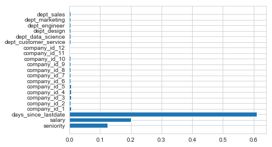

```python
# 20 trees:
rf = RandomForestClassifier(n_estimators = 20, random_state = 42,criterion='entropy')
rf.fit(X_train, y_train)
rf_importance20  = rf.feature_importances_
predicted_classes_rf = rf.predict(X_test)
predicted_prob_rf = rf.predict_proba(X_test)
plt.barh(X_train.columns, rf_importance20)

accuracy_rf = accuracy_score(y_test,predicted_classes_rf)


prob_retention_rf =[]
for i in range(len(predicted_prob_rf)):
    prob_retention_rf.append(predicted_prob_rf[i][1])
prfs= precision_recall_fscore_support(y_test, predicted_classes_rf, average='macro')
auc = metrics.roc_auc_score(y_test, prob_retention_rf)
print ('Logistic Regression Model with CV and Ridge: has accuracy of ' +str(accuracy_rf)+
       ', precision of ' +str(prfs[0])+ ', recall of ' +str(prfs[1])+ ', and AUC of '+str(auc) )
pd.crosstab(y_test, predicted_classes_rf, rownames=['Actual'], colnames=['Predicted'])
```

# Random Forest:

As the number of trees is increased in randomforest the fonal performance measures do not increase more that the slected model with 50 trees.